# Multilayer food webs

### backward or forward?

## VI Fritz Müller Seminar Series

### Rodrigo Cogni,

### Paulo R. Guimarães Jr,

### Tiago B. Quental,

### Patricia P. Coltri

## Thanks! Obrigado! Gracias!

[figure not shown]

### References

##### Biogeography

- Hutchinson, G. (1957). Concluding remarks. Cold Spring Harb. Symp. Quant. Biol., 22: 415-427.
- Holt, R. D. (2009). Bringing the Hutchinsonian niche into the 21st century: ecological and evolutionary perspectives. PNAS,106:19659-19665.
- Blonder, B. et al (2014). The N-dimensional hypervolume. Global Ecology and Biogeography, 23:595-609.
- Blonder, B. (2017). Hypervolume concepts in niche‐ and trait‐based ecology. Ecography, 41:1441-1455.
- Barros, C. et al. 2016. N‐dimensional hypervolumes to study stability of complex ecosystems. Ecol. Lett., 19:729–742.

#### Multivariate selection

- Lande (1980). The genetic covariance between characters mantained by pleiotropic mutations. Genetics, 94:203-215.
- Melo and Marroig (2015). Directional selection can drive the evolution of modularity in complex traits. PNAS, 112:470-475.
- Goswami et al (2015). The fossil record of phenotypic integration and modularity: A deep-time perspective on developmental and evolutionary dynamics. PNAS, 112:4891-4896.
- Assis et al. (2020). Genetic correlations and ecological networks shape coevolving mutualisms. Ecology Letters 23:1789-1799.

#### Genomics

- Boyle et al. (2017). An Expanded View of Complex Traits: From Polygenic to Omnigenic. Cell. 169:1177-1186.
- Svensson et al. (2021). Correlational selection in the age of genomics. Nature Ecology and Evolution. https://doi.org/10.1038/s41559-021-01413-3

#### Multilayer networks

- Sánchez-García et al. (2014). Dimensionality reduction and spectral properties of multilayer networks. Phys Rev E (Stat Nonlin Soft Matter Phys). 89:052815.
- De Domenico et al. (2015). Structural reducibility of multilayer networks. Nat. Commun., 6:6864 https://doi.org/10.1038/ncomms7864
- Melián et al. (2018). Deciphering the interdependence between ecological and evolutionary networks. TREE, 33:504-512.
- Guimarães PR Jr. (2020). The structure of ecological networks across levels of organization. Annual Review of Ecology, Evolution, and Systematics 51:433-460.

# How many layers explain global biodiversity patterns?

### Quantas camadas explicam os padrões de biodiversidade?

##### Cuantos niveles explican los patrones de la biodiversidad?

[figure not shown]

# How many layers? Quantas camadas? Cuantas capas?

The dream robot

$$$ pip install jupyter :: 1. sampling 2. models 3. species 4. hypo $ 1. rarefaction oky $ 2. model building strategy oky $ 3. species boundary oky $ 4. Hypo: Universal level oky $ RESPONSE -- UNIVERSAL EXPLAINS YOUR DATA oky dokky! ----------------------------------------------------------------- > Sampling? ## register jupyter > Model building strategy? ## register levix > Species boundaries? ## register mars > Hypo: Universal? Bottom up? Top down? Independent? Hybrids? Fluctuating? ##reg multiverse$$

# Rarefaction

[figure not shown]

# Model building strategy

[figure not shown]

# Model complexity reduction

[figure not shown]

# Species boundaries

[figure not shown]

```python
## UNIVERSAL

from IPython.display import HTML

HTML('<iframe width="560" height="315" src="https://upload.wikimedia.org/wikipedia/commons/1/13/Avida_host-parasite_coevolution_web.ogv" frameborder="0" allowfullscreen></iframe>')

#Title: Avida host-parasite coevolution web.ogv :: proxy genotype-phenotype map :: modularity vs integration
#Author: Miguel A. Fortuna
```

[interactive chart not shown]

## GAPS

[figure not shown]

# Sampling

$$$ pip install jupyter : sampling (pattern) $ pip install jupyter : sampling (process): species : level : time : space : trait ssssss $------------------------------------------------------------------ > Sampling interactions ## register jupyter$$

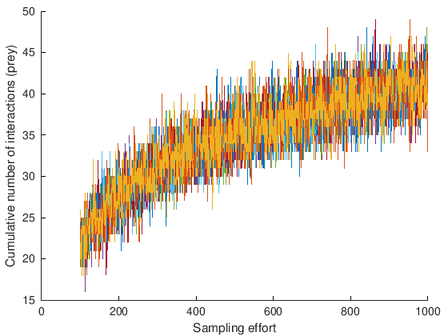

```python
### Rarefaction curves (Octave/Matlab)

%https://wiki.octave.org/Dataframe_package
%https://stackoverflow.com/questions/32504203/install-octave-package-manually
pkg load dataframe
pkg load statistics

%pkg update
%pkg installed

data = dataframe('datashow/StomachCodTest.csv');
g = data;
g_pred_code = g.pred_code;
a = cellstr(g_pred_code);
LIST = find(ismember(a, 'COD'));

b = data;
b_prey_sp_code = b.prey_sp_code;
b = cellstr(b_prey_sp_code);
%c = unique(b);
for i = 1:10;
count = 0;
for k = 100:1000;

    IndCOD = randsample(LIST,k);
    R = unique(b(IndCOD,1));
    count = count + 1;
    OUTPUT(count,1) = k;
    e = size(R);
    OUTPUT(count,2) = e(1,1);

end
hold on
plot(OUTPUT(:,1),OUTPUT(:,2))
end
xlabel('Sampling effort',"fontsize",14)
ylabel('Cumulative number of interactions (prey)',"fontsize",14)
set(gca,'fontsize',14);
```

# Rarefaction 10k

[figure not shown]

# Models

$$$ pip install jupyter : system biology $ pip install jupyter : genomics species $ pip install jupyter : community ecology $ pip install jupyter ; complex trait $------------------------------------------------------------------ > Modularity ## register levix > Omnigenic ## register levix > Master trait ## register levix > Complex trait ## register levix$$

## System biology

[figure not shown]

## Genomics

[figure not shown]

## Community Ecology

[figure not shown]

## Complex trait

[figure not shown]

## Species

$$$ pip install jupyter : biogeography $------------------------------------------------------------------ > BAM! ## register levix$$

# Biogeography

[figure not shown]

${\bf \Omega_{BAM}}$ = $\begin{bmatrix} V_B & C_{BA} & C_{BM} \\ C_{AB} & V_A & C_{AM} \\ C_{MB} & C_{MA} & V_M \end{bmatrix}$

$\mathbf{W}({\bf z})^{t}_{ix} = exp[-\gamma({\color{red}[{\bf z}^{t}_{ix} - {\bf \theta^{t}}_{ix}\color{red}]^T} {\bf \Omega_{BAM}}^{-1} {\color{red}[{\bf z}^{t}_{ix} - {\bf \theta^{t}}_{ix}\color{red}]})]$

$\underbrace{\begin{bmatrix} W({\bf z_{B}}^{t}_{ix}) \\ W({\bf z_{A}}^{t}_{ix}) \\ \vdots \\ W({\bf z_{M}}^{t}_{ix}) \\ \end{bmatrix} }_{\mathbf{W}}$ = $\underbrace{\begin{bmatrix} W({B}^{t}_{ix})^{*} \\ W({A}^{t}_{ix})^{*} \\ \vdots \\ W({M}^{t}_{ix})^{*} \\ \end{bmatrix}^{T} }_{\mathbf{W}}$ $\underbrace{\begin{bmatrix} V_{B} & C_{BA} & \dots & C_{BM} \\ C_{AB} & V_{A} & \dots & C_{AM} \\ \vdots & \vdots & \vdots & \vdots \\ C_{MB} & C_{MA} & \dots & V_{M} \\ \end{bmatrix}^{-1} }_{\mathbf{\Omega_{BAM}}}$ $\underbrace{\begin{bmatrix} W({B}^{t}_{ix})^{*} \\ W({A}^{t}_{ix})^{*} \\ \vdots \\ W({M}^{t}_{ix})^{*} \\ \end{bmatrix} }_{\mathbf{W}}$

[figure not shown]

## Hypo:

### The big 4 layers (the grand scheme of things)

#### System Biology -- Genomics -- Phenome -- Biogeography

##### Universal? Bottom up?Top down? Independent? Hybrids? Fluctuating?

[figure not shown]

#### Take home message

### Mensaje para llevar a casa

## Levar mensagem para casa

# How many layers? Quantas camadas? Cuantas capas?

## The real robot

$$$ pip install jupyter :: 1. sampling 2. models 3. species 4. hypo $ 1. rarefaction $ 2. model building strategy $ 3. species boundary $ 4. Hypo: Universal? Bottom up? Independent? Hybrids? Fluctuating? $------------------------------------------------------------------ > RESPONSE 1 ## Strong bias in samplings observed in rarefaction curves > RESPONSE 2 ## Multilayer neural network along a complexity gradient > RESPONSE 3 ## No species boundary found -- infinite variance observed > RESPONSE 4 ## Combination of hypothesis with fluctuating layers$$